# 解析レポート

Author

Author Name

Published

February 27, 2025

解析ソフトウェア

```
[1] "R version 4.4.1 (2024-06-14 ucrt)"
```

# 1 ライブラリの読み込み

# 2 データの読み込みと確認

## 2.1 データの基本情報

```
データの行数: 1510
```

```
データの列数: 13
```

各変数のデータ型

|  | 変数名 | データ型 |
| --- | --- | --- |
| ID | ID | integer |
| visit_date | visit_date | character |
| age | age | integer |
| sex | sex | integer |
| race | race | integer |
| weight | weight | numeric |
| height | height | numeric |
| smoke | smoke | integer |
| drink | drink | integer |
| regular_exercise | regular_exercise | integer |
| interv | interv | integer |
| HbA1c | HbA1c | character |
| CRE | CRE | numeric |

各変数の欠損値

|  | 変数名 | 欠損数 | 欠損率 |
| --- | --- | --- | --- |
| ID | ID | 0 | 0.00 |
| visit_date | visit_date | 0 | 0.00 |
| age | age | 0 | 0.00 |
| sex | sex | 0 | 0.00 |
| race | race | 0 | 0.00 |
| weight | weight | 0 | 0.00 |
| height | height | 0 | 0.00 |
| smoke | smoke | 0 | 0.00 |
| drink | drink | 0 | 0.00 |
| regular_exercise | regular_exercise | 0 | 0.00 |
| interv | interv | 0 | 0.00 |
| HbA1c | HbA1c | 287 | 19.01 |
| CRE | CRE | 0 | 0.00 |

# 3 データハンドリング

## 3.1 データ前処理の概要

```
データ前処理の概要:
```

```
1. 変数の型変換（日付型、因子型など）
```

```
2. BMIとクレアチニンクリアランス（CrCL）の計算
```

```
3. 患者ごとの初回・最終来院日の特定
```

```
4. イベント（HbA1c >= 7）の定義
```

```
5. 除外基準の適用（初回来院時にHbA1c >= 7または欠測の患者を除外）
```

```
6. 解析用データセットの作成（baseline, event_date, df_merged）
```

```
前処理後のデータサイズ:
```

```
- 元データ:  1510 行 x 13 列
```

```
- 処理済みデータ:  1510 行 x 18 列
```

```
- 除外後データ:  1062 行 x 18 列
```

```
- ベースラインデータ:  217 行 x 18 列
```

```
- 解析用データ（df_merged）:  217 行 x 23 列
```

# 4 解析1: 患者背景表の作成

| **変数** | **Overall** N = 217<sup>1</sup> | **介入群** **対照群** N = 112<sup>1</sup> | **介入群** **介入群** N = 105<sup>1</sup> | **p-value**<sup>2</sup> |  |
| --- | --- | --- | --- | --- | --- |
| 年齢 | 51.0 (44.0, 57.0) | 51.0 (43.5, 57.0) | 51.0 (44.0, 56.0) |  | 0.9 |
| 年齢カテゴリ |  |  |  | >0.9 |  |
| 40歳以下 | 37 (17%) | 20 (18%) | 17 (16%) |  |  |
| 41-60歳 | 150 (69%) | 77 (69%) | 73 (70%) |  |  |
| 61-80歳 | 30 (14%) | 15 (13%) | 15 (14%) |  |  |
| 81歳以上 | 0 (0%) | 0 (0%) | 0 (0%) |  |  |
| 性別 |  |  |  | 0.15 |  |
| 男性 | 115 (53%) | 54 (48%) | 61 (58%) |  |  |
| 女性 | 102 (47%) | 58 (52%) | 44 (42%) |  |  |
| 人種 |  |  |  | 0.8 |  |
| 白人 | 114 (53%) | 58 (52%) | 56 (53%) |  |  |
| 黒人 | 54 (25%) | 30 (27%) | 24 (23%) |  |  |
| その他 | 49 (23%) | 24 (21%) | 25 (24%) |  |  |
| 喫煙状況 |  |  |  | 0.4 |  |
| 非喫煙 | 145 (67%) | 78 (70%) | 67 (64%) |  |  |
| 喫煙 | 72 (33%) | 34 (30%) | 38 (36%) |  |  |
| 飲酒状況 |  |  |  | 0.5 |  |
| 飲酒なし | 129 (59%) | 64 (57%) | 65 (62%) |  |  |
| 飲酒あり | 88 (41%) | 48 (43%) | 40 (38%) |  |  |
| クレアチニンクリアランス | 173.2 (103.5, 278.2) | 190.8 (104.3, 261.4) | 162.4 (103.5, 291.2) | >0.9 |  |
| クレアチニンクリアランスカテゴリ |  |  |  | 0.4 |  |
| 30未満 | 1 (0.5%) | 0 (0%) | 1 (1.0%) |  |  |
| 30-60 | 11 (5.1%) | 7 (6.3%) | 4 (3.8%) |  |  |
| 60以上 | 205 (94%) | 105 (94%) | 100 (95%) |  |  |
| BMI | 24.6 (21.4, 28.8) | 25.9 (21.8, 28.9) | 23.8 (20.8, 28.4) | 0.071 |  |
| 運動習慣 |  |  |  | 0.5 |  |
| なし | 55 (25%) | 27 (24%) | 28 (27%) |  |  |
| 週1-2回 | 65 (30%) | 30 (27%) | 35 (33%) |  |  |
| 週3-4回 | 73 (34%) | 40 (36%) | 33 (31%) |  |  |
| 週5回以上 | 24 (11%) | 15 (13%) | 9 (8.6%) |  |  |

<sup>1</sup> Median (Q1, Q3); n (%)  
<sup>2</sup> Wilcoxon rank sum test; Fisher’s exact test; Pearson’s Chi-squared test

# 5 解析2: 生存時間解析

## 5.1 解析2-1: カプランマイヤー曲線の作成

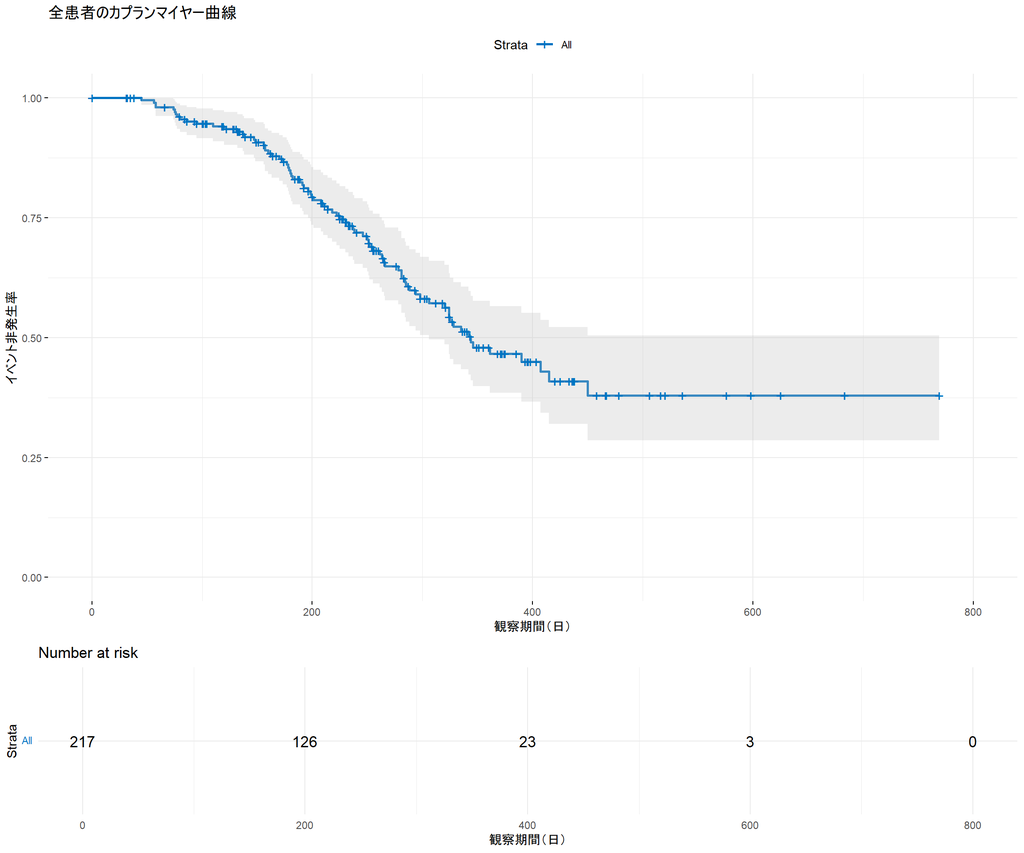

## 5.2 解析2-2: 介入群別のカプランマイヤー曲線

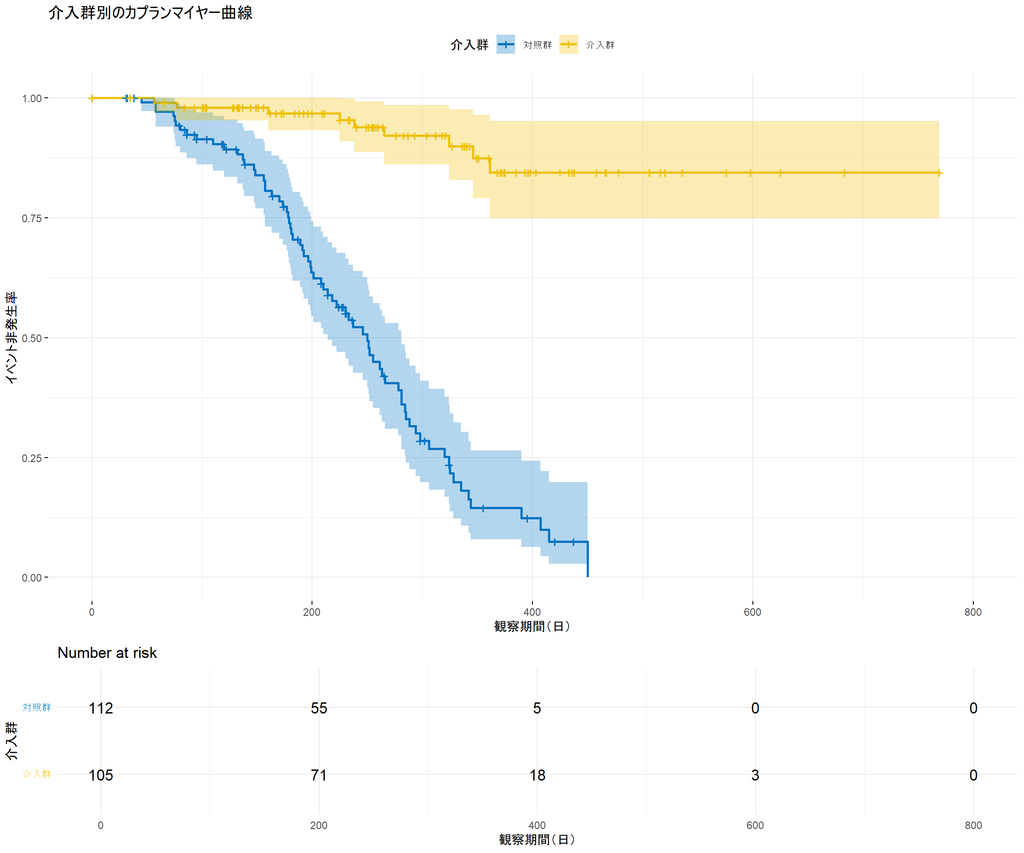

## 5.3 解析2-3: Cox比例ハザードモデル

| **Characteristic** | **HR** | **95% CI** | **p-value** |
| --- | --- | --- | --- |
| 介入群 |  |  | <0.001 |
| 対照群 | — | — |  |
| 介入群 | 0.14 | 0.04, 0.43 |  |
| 年齢 | 0.98 | 0.96, 1.01 | 0.2 |
| 性別 |  |  | 0.6 |
| 男性 | — | — |  |
| 女性 | 0.89 | 0.53, 1.48 |  |
| 人種 |  |  | >0.9 |
| 白人 | — | — |  |
| 黒人 | 0.97 | 0.52, 1.80 |  |
| その他 | 1.07 | 0.55, 2.08 |  |
| 喫煙状況 |  |  | 0.7 |
| 非喫煙 | — | — |  |
| 喫煙 | 1.11 | 0.64, 1.94 |  |
| 飲酒状況 |  |  | 0.6 |
| 飲酒なし | — | — |  |
| 飲酒あり | 0.87 | 0.53, 1.43 |  |
| クレアチニンクリアランス | 1.00 | 1.00, 1.00 | 0.9 |
| BMI | 1.03 | 0.98, 1.07 | 0.3 |
| 運動習慣 |  |  | 0.5 |
| なし | — | — |  |
| 週1-2回 | 1.68 | 0.78, 3.64 |  |
| 週3-4回 | 1.12 | 0.53, 2.37 |  |
| 週5回以上 | 0.97 | 0.41, 2.27 |  |
| 介入群と運動習慣の交互作用 |  |  | 0.2 |
| 介入群 * 週1-2回 | 0.12 | 0.01, 1.27 |  |
| 介入群 * 週3-4回 | 0.59 | 0.11, 3.20 |  |
| 介入群 * 週5回以上 | 0.76 | 0.07, 8.16 |  |

Abbreviations: CI = Confidence Interval, HR = Hazard Ratio

## 5.4 解析2-4: 運動習慣サブグループごとのカプランマイヤー曲線

[figure not shown]

# 6 結論

# 7 Statistical Analysis

Continuous variables were summarized as median with interquartile range (IQR), and categorical variables were presented as frequencies and percentages. Baseline characteristics were compared between the intervention and control groups using the Wilcoxon rank-sum test for continuous variables and the chi-square test or Fisher’s exact test for categorical variables, as appropriate.

The primary outcome was the time to HbA1c level ≥7.0%. Patients who did not experience the event during the observation period were censored at their last visit date. Kaplan-Meier curves were constructed to visualize the cumulative incidence of the primary outcome, and the log-rank test was used to compare differences between groups. Patients with HbA1c ≥7.0% or missing HbA1c values at baseline were excluded from the analysis.

Cox proportional hazards regression models were used to estimate hazard ratios (HRs) and 95% confidence intervals (CIs) for the association between the intervention and the primary outcome. The multivariable model was adjusted for age, sex, race, smoking status, alcohol consumption, creatinine clearance (CrCL), body mass index (BMI), and regular exercise. CrCL was calculated using the Cockcroft-Gault formula, with a 0.85 multiplication factor for female patients. BMI was calculated as weight in kilograms divided by height in meters squared.

To evaluate potential effect modification by exercise habits, an interaction term between intervention status and regular exercise was included in the Cox model. Additionally, subgroup analyses were performed by stratifying patients according to their exercise frequency (none, 1-2 times/week, 3-4 times/week, ≥5 times/week).

# 8 Results

## 8.1 Patient Characteristics

In this study, a total of 300 patients with type 2 diabetes were enrolled, of whom 83 were excluded due to meeting exclusion criteria, resulting in 217 patients for the final analysis. The median age of the subjects was 51.0 years (interquartile range: 44.0-57.0), with 115 males (53%) and 102 females (47%). By race, there were 114 Whites (53%), 54 Blacks (25%), and 49 others (23%).

Patients were randomly assigned to the intervention group (n=105) or the control group (n=112). There were no significant differences in patient background characteristics between the two groups (Table 1). The median BMI was 23.8 (interquartile range: 20.8-28.4) in the intervention group and 25.9 (interquartile range: 21.8-28.9) in the control group, showing a slightly lower trend in the intervention group, but this did not reach statistical significance (p=0.071).

Regarding regular exercise habits, 55 patients (25%) had no exercise, 65 patients (30%) exercised 1-2 times per week, 73 patients (34%) exercised 3-4 times per week, and 24 patients (11%) exercised 5 or more times per week. There was no significant difference in the distribution of exercise habits between the two groups (p=0.5).

## 8.2 Primary Outcome

The median observation period was 228 days, with 80 patients (37%) experiencing the event of HbA1c ≥7.0% and 137 patients (63%) being censored. In the overall Kaplan-Meier curve, the median time to event was 344 days (95% confidence interval: 306 days to upper limit not estimable).

In the Kaplan-Meier curves comparing the intervention and control groups, the median time to event in the control group was 250 days (95% confidence interval: 214-281 days), whereas the intervention group did not reach the median time to event within the observation period. The log-rank test showed a statistically significant difference between the two groups (p<0.001).

Multivariate Cox proportional hazards model analysis showed that, even after adjusting for age, sex, race, smoking status, alcohol consumption, creatinine clearance, BMI, and exercise habits, the intervention group had a significantly lower risk of event occurrence compared to the control group (hazard ratio [HR]=0.14, 95% confidence interval [CI]: 0.04-0.43, p<0.001).